# balci2010()

Interval timing tasks play a crucial role in understanding temporal processing mechanisms of a wide variety of organisms. Peak procedure trials are a common method used in experimental behavior analysis to study timing behavior. The analysis of single-trials in the peak procedure was introduced by Church et al. (1994) to test some predictions of the Scalar Expectancy Theory (SET) about the variability of decision thresholds in interval timing.

[Balci and colleagues (2010)](https://doi.org/10.1016/j.brainres.2010.02.034) introduced a comprehensive approach to dissecting the dynamics of response rates in such tasks. The key parameters of single-trial analysis include:

- `start` time, which denotes response onset post-stimulus presentation and correspond to the point at which the data first exceeds 70% of the maximum response rate.
- `stop` time, which marks task disengagement, corresponding to the time at which response rate first fell below 70%.
- `width` or `spread`, quantifies duration between start and stop, indicating temporal response dispersion.

*Note that these values are calculated using the moving average of the normalized response rates.*

The `balci2010()` function implements an individual peak procedure trial analyisis using moving average. Given a pair of time bins and normalized response rate vectors, the function returns a two item list with a numeric vector including `start` and `stop` times, `spread` and `argmax` values, the latter indicating the bin at which response rate is at its maximum, and a numeric vector for the `mov_av` (moving average) values for each time bin.

The `balci2010()` function takes the following parameters:

- `rate_norm` a numeric vector with the normalized response rate data points.
- `bines` a numeric vector with the corresponding time bins for each response rate data point.

## Example

First let’s load a data sample of response times:

```r
data("r_times")

head(r_times, n=30)
```

```
##  [1] 28.1 40.7 44.2 44.4 44.7 45.0 45.4 47.9 48.1 48.3 48.6 48.8 49.8 50.2 50.7
## [16] 51.2 51.4 51.7 51.9 52.7 53.0 53.5 53.7 53.9 54.1 54.3 54.9 55.3 55.5 55.7
```

Now we will use the `get_bins()` function included in this package (see `get_bins.Rmd` for further details) to convert the raw data points into time bins and then create a frequency table with the `f_table` function, also included in this package (see `f_table.Rmd` for further details):

```r
bines <- get_bins(r_times, 0, 180, 2) # Binarize r_times to create a response rate distribution of 2 sec. bins.

bin_res <- 6
response_rate <- f_table(bines, 0, 180, bin_res)
res_rate_norm <- response_rate$prop / max(response_rate$prop) # Normalize the response rate values.
bines <- response_rate$bins # Get the time bins vector.
```

Finally let’s use the `balci2010` function to extract the `start`,`stop`, `widht` and `argmax` values, as well as the moving average and plot them respectively.

```r
balci_ind <- balci2010(res_rate_norm, bines)

balci_ind$params
```

```
## [1] 72 90 18 78
```

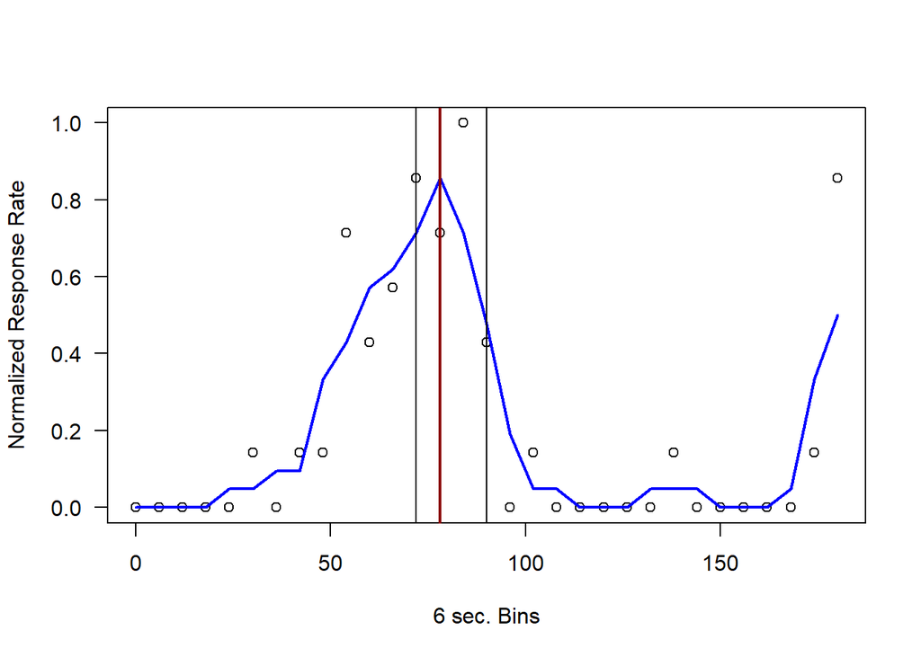